# Weather and Corn Yield Regressions

## Assignment

### Question 1a: Extract Winneshiek County corn yields, fit a linear time trend, make a plot. Is there a significant time trend?

```r
cornyields_winn <- cornyields %>%
  filter(county_name == "WINNESHIEK")

lm_cornyields_winn <- lm(yield ~ year, cornyields_winn)
summary(lm_cornyields_winn)
```

```
##
## Call:
## lm(formula = yield ~ year, data = cornyields_winn)
##
## Residuals:
##     Min      1Q  Median      3Q     Max
## -51.163  -1.841   2.363   9.437  24.376
##
## Coefficients:
##              Estimate Std. Error t value Pr(>|t|)
## (Intercept) -4763.290    448.286  -10.63 4.46e-13 ***
## year            2.457      0.224   10.96 1.77e-13 ***
## ---
## Signif. codes:  0 '***' 0.001 '**' 0.01 '*' 0.05 '.' 0.1 ' ' 1
##
## Residual standard error: 16.97 on 39 degrees of freedom
## Multiple R-squared:  0.7551, Adjusted R-squared:  0.7488
## F-statistic: 120.2 on 1 and 39 DF,  p-value: 1.767e-13
```

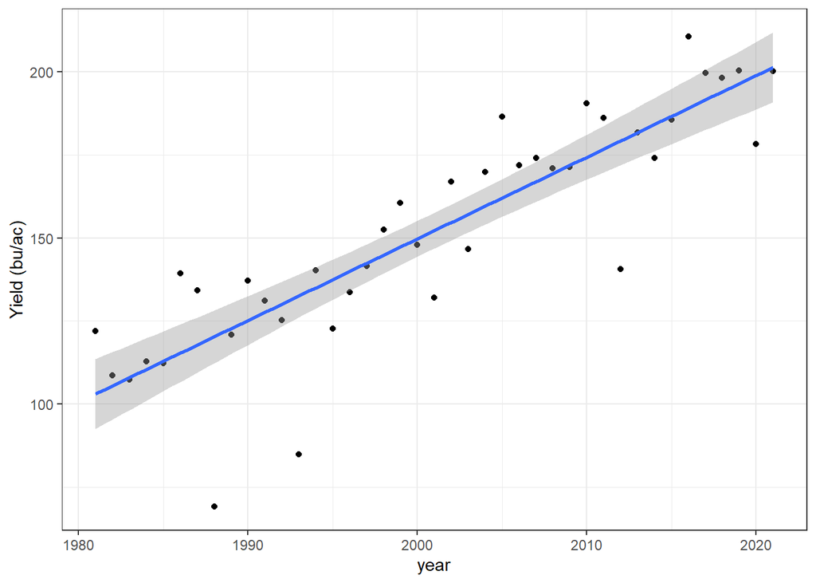

```r
ggplot(cornyields_winn, mapping = aes(x = year, y = yield)) +
  geom_point() +
  theme_bw() +
  labs(x = "year", y = "Yield (bu/ac)") +
  geom_smooth(method = lm)
```

There is absolutely a strong linear trend between yield and year. It appears that as time progresses, yield increases near linearly.

### Question 1b: Fit a quadratic time trend (i.e., year + year^2) and make a plot. Is there evidence for slowing yield growth?

```r
cornyields_winn$yearsq <- cornyields_winn$year^2
lm_cornyieldsquad <- lm(yield ~ year + yearsq, cornyields_winn)
summary(lm_cornyieldsquad)
```

```
##
## Call:
## lm(formula = yield ~ year + yearsq, data = cornyields_winn)
##
## Residuals:
##     Min      1Q  Median      3Q     Max
## -51.384  -3.115   1.388   9.743  25.324
##
## Coefficients:
##               Estimate Std. Error t value Pr(>|t|)
## (Intercept)  2.583e+04  8.580e+04   0.301    0.765
## year        -2.812e+01  8.576e+01  -0.328    0.745
## yearsq       7.641e-03  2.143e-02   0.357    0.723
##
## Residual standard error: 17.17 on 38 degrees of freedom
## Multiple R-squared:  0.7559, Adjusted R-squared:  0.7431
## F-statistic: 58.84 on 2 and 38 DF,  p-value: 2.311e-12
```

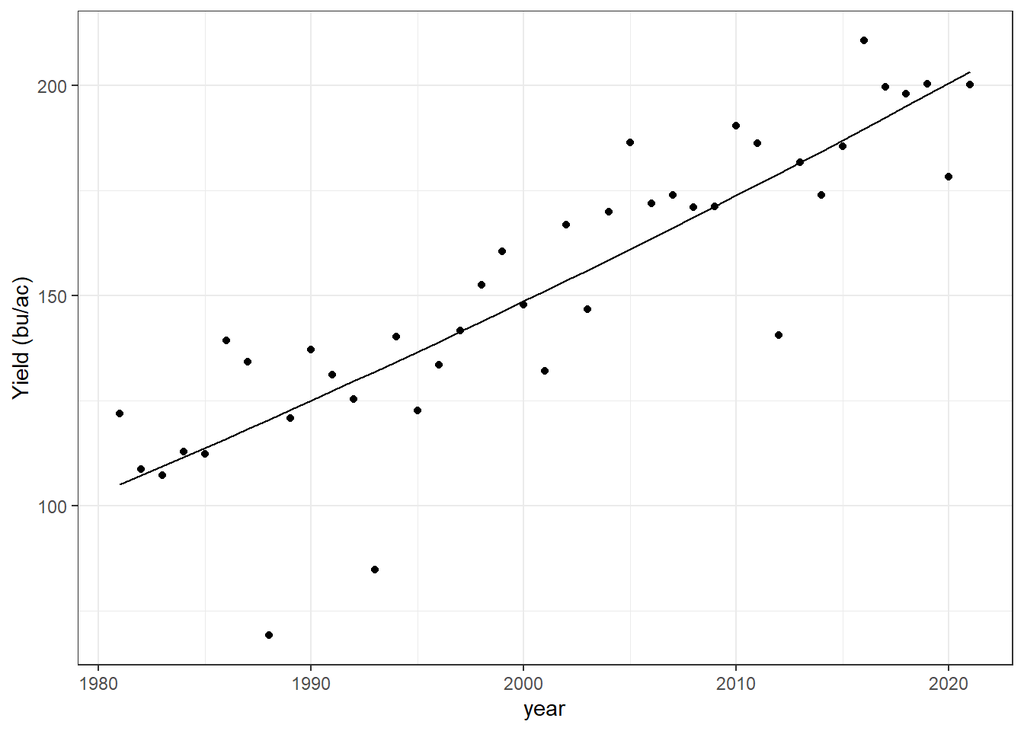

```r
cornyields_winn$fitted <- lm_cornyieldsquad$fitted.values
ggplot(cornyields_winn) +
  geom_point(mapping = aes(x = year, y = yield)) +
  geom_line(mapping = aes(x = year, y = fitted)) +
  theme_bw() +
  labs(x = "year", y = "Yield (bu/ac)")
```

While a quadratic trend certainly exists between yield and year, the slight upward bend to the fitted curve indicates that there is not evidence for slowing yield growth. If anything, yield is growing slightly faster, though not to a level that is apparently different than a linear fit. It seems as though a linear fit for yield growth is as appropriate as a quadratic fit over this time period.

### Question 2 – Time Series: Let’s analyze the relationship between temperature and yields for the Winneshiek County time series. Use data on yield and summer avg Tmax. Is adding year or Tmax^2 to your model helpful? Make a plot and interpret the results.

```r
yield_temp_summer <- inner_join(winnesummer, cornyields_winn, by = "year") %>%
  mutate(Tmaxsq = (meantmax^2))

lm_temp_yield <- lm(yield ~ meantmax, yield_temp_summer)
summary(lm_temp_yield)
```

```
##
## Call:
## lm(formula = yield ~ meantmax, data = yield_temp_summer)
##
## Residuals:
##    Min     1Q Median     3Q    Max
## -71.96 -19.85  -3.19  24.64  61.72
##
## Coefficients:
##             Estimate Std. Error t value Pr(>|t|)
## (Intercept)  275.876    118.335   2.331   0.0255 *
## meantmax      -4.763      4.438  -1.073   0.2902
## ---
## Signif. codes:  0 '***' 0.001 '**' 0.01 '*' 0.05 '.' 0.1 ' ' 1
##
## Residual standard error: 32.88 on 36 degrees of freedom
## Multiple R-squared:  0.03101,    Adjusted R-squared:  0.004098
## F-statistic: 1.152 on 1 and 36 DF,  p-value: 0.2902
```

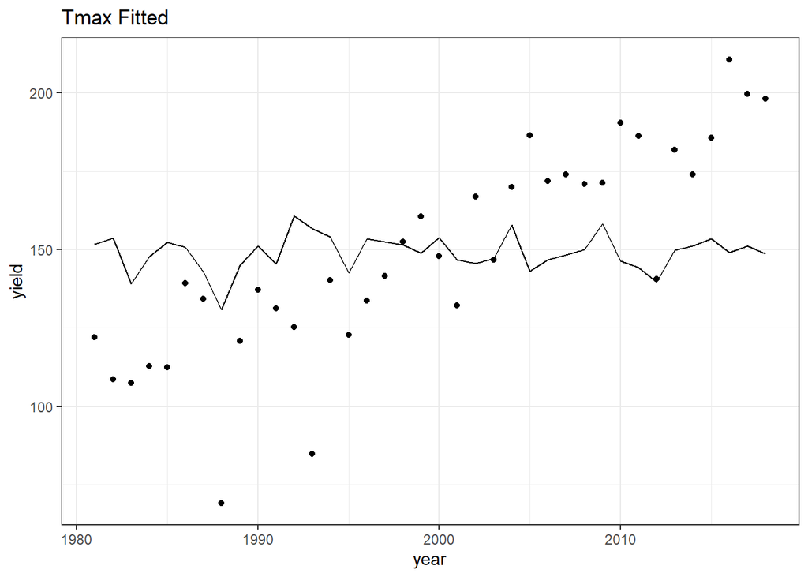

```r
yield_temp_summer$fitted_3 <- lm_temp_yield$fitted.values
ggplot(yield_temp_summer) +
  geom_point(mapping = aes(x = year, y = yield)) +
  geom_line(mapping = aes(x = year, y = fitted_3)) +
  theme_bw() +
  labs(x = "year", y = "yield", title = "Tmax Fitted")
```

```r
lm_temp_year_yield <- lm(yield ~ year + meantmax, yield_temp_summer)
summary(lm_temp_year_yield)
```

```
##
## Call:
## lm(formula = yield ~ year + meantmax, data = yield_temp_summer)
##
## Residuals:
##     Min      1Q  Median      3Q     Max
## -53.071  -7.269   2.271   9.935  27.505
##
## Coefficients:
##              Estimate Std. Error t value Pr(>|t|)
## (Intercept) -4791.774    513.812  -9.326 5.10e-11 ***
## year            2.514      0.253   9.934 1.01e-11 ***
## meantmax       -3.201      2.308  -1.387    0.174
## ---
## Signif. codes:  0 '***' 0.001 '**' 0.01 '*' 0.05 '.' 0.1 ' ' 1
##
## Residual standard error: 17.06 on 35 degrees of freedom
## Multiple R-squared:  0.7463, Adjusted R-squared:  0.7318
## F-statistic: 51.48 on 2 and 35 DF,  p-value: 3.761e-11
```

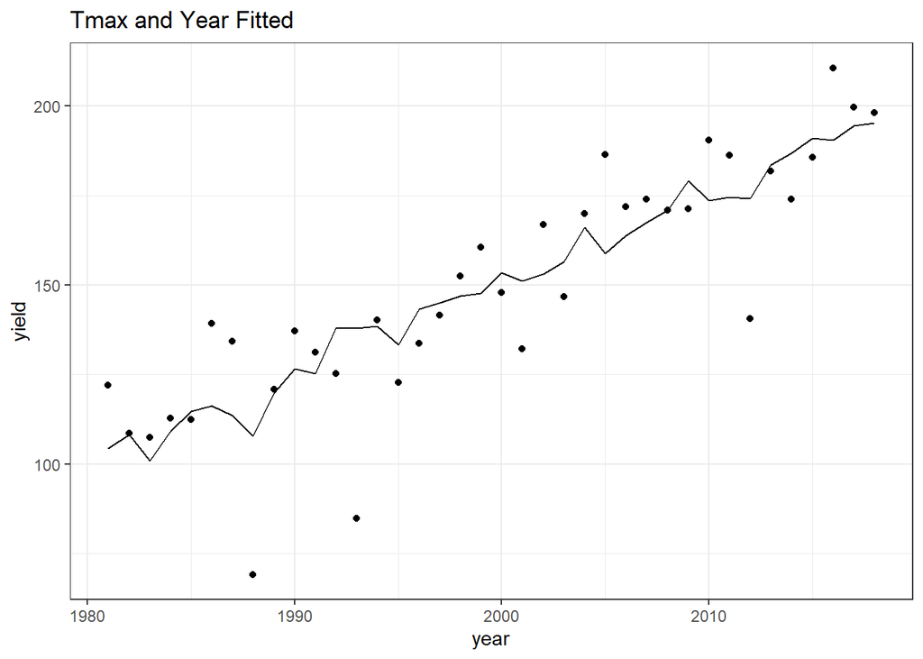

```r
yield_temp_summer$fitted <- lm_temp_year_yield$fitted.values
ggplot(yield_temp_summer) +
  geom_point(mapping = aes(x = year, y = yield)) +
  geom_line(mapping = aes(x = year, y = fitted)) +
  theme_bw() +
  labs(x = "year", y = "yield", title = "Tmax and Year Fitted")
```

```r
lm_temp_tmax2_yield <- lm(yield ~ Tmaxsq + meantmax, yield_temp_summer)
summary(lm_temp_tmax2_yield)
```

```
##
## Call:
## lm(formula = yield ~ Tmaxsq + meantmax, data = yield_temp_summer)
##
## Residuals:
##     Min      1Q  Median      3Q     Max
## -56.587 -22.262  -0.982  22.409  52.798
##
## Coefficients:
##              Estimate Std. Error t value Pr(>|t|)
## (Intercept) -4223.604   1446.639  -2.920  0.00609 **
## Tmaxsq         -6.173      1.979  -3.119  0.00362 **
## meantmax      328.918    107.068   3.072  0.00410 **
## ---
## Signif. codes:  0 '***' 0.001 '**' 0.01 '*' 0.05 '.' 0.1 ' ' 1
##
## Residual standard error: 29.5 on 35 degrees of freedom
## Multiple R-squared:  0.2417, Adjusted R-squared:  0.1984
## F-statistic: 5.579 on 2 and 35 DF,  p-value: 0.007887
```

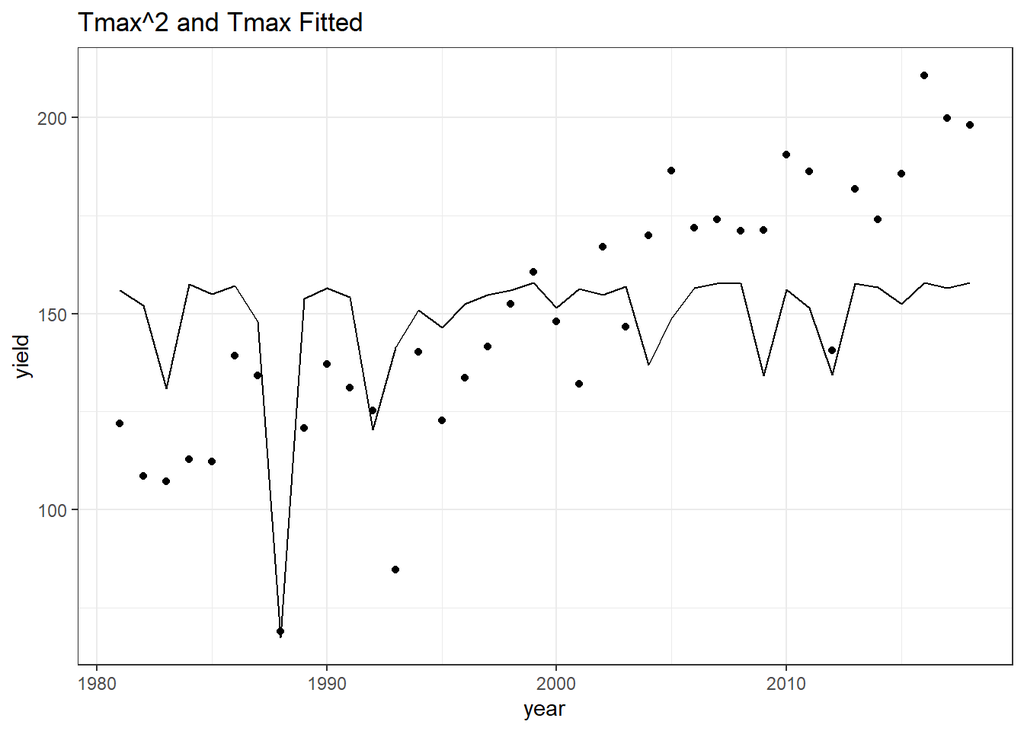

```r
yield_temp_summer$fitted_2 <- lm_temp_tmax2_yield$fitted.values
ggplot(yield_temp_summer) +
  geom_point(mapping = aes(x = year, y = yield)) +
  geom_line(mapping = aes(x = year, y = fitted_2)) +
  theme_bw() +
  labs(x = "year", y = "yield", title = "Tmax^2 and Tmax Fitted")
```

### Question 3 – Cross-Section: Analyze the relationship between temperature and yield across all counties in 2018. Is there a relationship? Interpret the results.

```r
cornyields$countyfp <- as.factor(cornyields$county_ansi)

tmax_all <- tmaxdf %>%
  filter(year == 2018) %>%
  select(countyfp, tmax) %>%
  group_by(countyfp) %>%
  summarize(meantmax = mean(tmax, na.rm = TRUE))

cornyields_2018 <- cornyields %>%
  filter(year == 2018)

all_county <- inner_join(cornyields_2018, tmax_all, by = "countyfp") %>%
  mutate(Tmaxsq = (meantmax^2))

lm_cornyields_2018<- lm(yield ~ meantmax + Tmaxsq, all_county)
summary(lm_cornyields_2018)
```

```
##
## Call:
## lm(formula = yield ~ meantmax + Tmaxsq, data = all_county)
##
## Residuals:
##     Min      1Q  Median      3Q     Max
## -47.621 -13.029   4.092  13.404  33.532
##
## Coefficients:
##             Estimate Std. Error t value Pr(>|t|)
## (Intercept) -944.797    230.011  -4.108 8.79e-05 ***
## meantmax     165.992     33.316   4.982 3.02e-06 ***
## Tmaxsq        -6.002      1.199  -5.007 2.74e-06 ***
## ---
## Signif. codes:  0 '***' 0.001 '**' 0.01 '*' 0.05 '.' 0.1 ' ' 1
##
## Residual standard error: 17.78 on 90 degrees of freedom
## Multiple R-squared:  0.2192, Adjusted R-squared:  0.2018
## F-statistic: 12.63 on 2 and 90 DF,  p-value: 1.46e-05
```

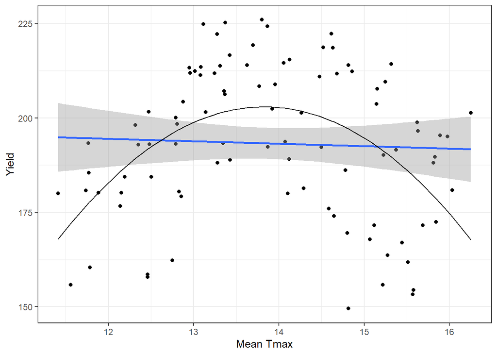

```r
all_county$fitted <- lm_cornyields_2018$fitted.values

ggplot(all_county, mapping = aes(x = meantmax, y = yield)) +
  geom_point() +
  theme_bw() +
  labs(x = "Mean Tmax", y = "Yield") +
  geom_smooth(method = lm) +
  geom_line(mapping = aes(x = meantmax, y = fitted))
```

### Question 4 – Panel: One way to leverage multiple time series is to group all data into what is called a “panel” regression. Convert the county ID code (“countyfp” or “county_ansi”) into factor using as.factor, then include this variable in a regression using all counties’ yield and summer temperature data. How does the significance of your temperature coefficients (Tmax, Tmax^2) change? Make a plot comparing actual and fitted yields and interpret the results of your model.

```r
all_county_years <- inner_join(cornyields, tmax_all, by = "countyfp") %>%
  mutate(Tmaxsq = (meantmax^2))

lm_cornyields_2018_4<- lm(yield ~ meantmax + Tmaxsq + countyfp, all_county_years)
summary(lm_cornyields_2018_4)
```

```
##
## Call:
## lm(formula = yield ~ meantmax + Tmaxsq + countyfp, data = all_county_years)
##
## Residuals:
##      Min       1Q   Median       3Q      Max
## -115.150  -22.076   -0.895   25.952   82.566
##
## Coefficients: (2 not defined because of singularities)
##               Estimate Std. Error t value Pr(>|t|)
## (Intercept) -381.78823  407.55027  -0.937  0.34893
## meantmax      86.81961   62.53772   1.388  0.16513
## Tmaxsq        -3.49255    2.37509  -1.470  0.14151
## countyfp3      0.26558    9.13920   0.029  0.97682
## countyfp5     -6.83971    7.63880  -0.895  0.37063
## countyfp7      3.06656   15.77143   0.194  0.84584
## countyfp9      1.03300    7.18641   0.144  0.88571
## countyfp11     2.65219    7.22725   0.367  0.71366
## countyfp13    -1.63277    7.77441  -0.210  0.83366
## countyfp15     8.66470    7.21086   1.202  0.22958
## countyfp17     1.57130    7.76668   0.202  0.83968
## countyfp19     0.49318    7.77725   0.063  0.94944
## countyfp21    -2.98911    7.62213  -0.392  0.69496
## countyfp23    -1.03352    7.78723  -0.133  0.89442
## countyfp25     0.33920    7.78172   0.044  0.96523
## countyfp27     2.01618    7.49725   0.269  0.78800
## countyfp29     8.41353    7.66424   1.098  0.27237
## countyfp31    17.49833    7.24880   2.414  0.01583 *
## countyfp33    -5.92906    6.95888  -0.852  0.39426
## countyfp35     0.71096    7.78291   0.091  0.92722
## countyfp37    -7.33488    7.13910  -1.027  0.30428
## countyfp39   -12.69943   12.08428  -1.051  0.29337
## countyfp41    -5.60357    7.27194  -0.771  0.44101
## countyfp43    -0.27005    7.79961  -0.035  0.97238
## countyfp45    11.54396    7.10072   1.626  0.10408
## countyfp47    -0.61022    7.62241  -0.080  0.93620
## countyfp49     9.81607    7.29331   1.346  0.17841
## countyfp51     7.23398   17.60658   0.411  0.68119
## countyfp53     1.74160   15.40841   0.113  0.91001
## countyfp55     0.77350    7.79566   0.099  0.92097
```

[output cut: 62 more lines]

```
## countyfp181    4.94287   10.12913   0.488  0.62559
## countyfp183   17.84754   10.41186   1.714  0.08658 .
## countyfp185   -3.40347   13.69701  -0.248  0.80377
## countyfp187    4.06645    7.79745   0.522  0.60204
## countyfp189   -0.09226    6.87825  -0.013  0.98930
## countyfp191   -5.52267    7.09939  -0.778  0.43667
## countyfp193   -6.56075    7.56650  -0.867  0.38595
## countyfp195         NA         NA      NA       NA
## countyfp197         NA         NA      NA       NA
## ---
## Signif. codes:  0 '***' 0.001 '**' 0.01 '*' 0.05 '.' 0.1 ' ' 1
##
## Residual standard error: 34.65 on 3916 degrees of freedom
## Multiple R-squared:  0.1048, Adjusted R-squared:  0.08245
## F-statistic:  4.68 on 98 and 3916 DF,  p-value: < 2.2e-16
```

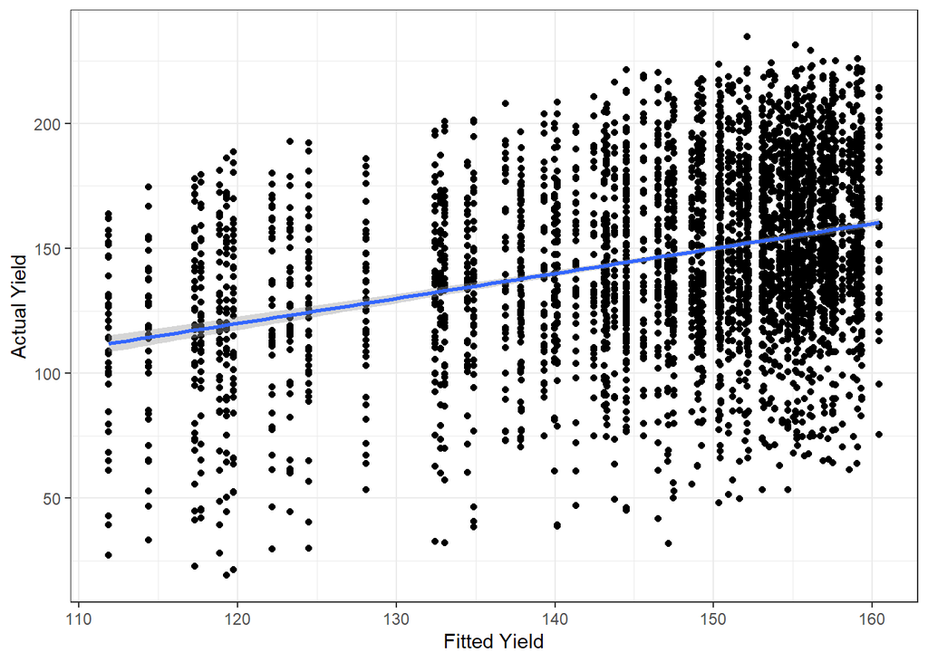

```r
all_county_years$fitted_4 <- lm_cornyields_2018_4$fitted.values

ggplot(all_county_years, mapping = aes(x = fitted_4, y = yield)) +
  geom_point() +
  theme_bw() +
  labs(x = "Fitted Yield", y = "Actual Yield") +
  geom_smooth(method = lm)
```

It seems that fitted yield and actual yield are related, but the spread of residuals is a little concerning. It seems like the significance of my temperature coefficiencts change a lot, and now none of them have a p-value < 0.05 (meantmax = 0.165, Tmaxsq = 0.142 ). Overall, the fitted model does have a positive linear relationship with the actual yield in each county, but the spread and residuals are so great that I am a little doubtful of the model’s effectiveness. The p-value for model is 2.2e-16, but I feel that this is because there are so many degrees of freedom, rather than an accurate evaluation of the model. We may may our p-value too small by choosing too many variables. This is somewhat supported by the R-squared value of 0.082. I would feel a lot more comfortable making conclusions using one of my earlier models, particularly because they showed that year has a greater impact on yield than summer temperatures. However, I do think this model does a pretty decent job at estimating yield.

### Question 5 – Soybeans: Download NASS data on soybean yields and explore either a time series relationship for a given county, the cross-sectional relationship for a given year, or a panel across all counties and years.

```r
# set our API key with NASS
nassqs_auth(key = "C8B5375C-D03A-3E4D-AF9E-90078918CDBA")
# parameters to query on
params_s <- list(commodity_desc = "SOYBEANS", statisticcat_desc = "YIELD", prodn_practice_desc = "ALL PRODUCTION PRACTICES", year__GE = 1981, state_alpha = "IA")
# download
beanyieldsall <- nassqs_yields(params_s)
beanyieldsall$county_ansi <- as.numeric(beanyieldsall$county_ansi)
beanyieldsall$yield <- as.numeric(beanyieldsall$Value)
# clean and filter this dataset
beanyields <- select(beanyieldsall, county_ansi, county_name, yield, year) %>%
  filter(!is.na(county_ansi) & !is.na(yield))
beanyields <- tibble(beanyields)

beanyields$countyfp <- as.factor(beanyields$county_ansi)

all_county_years_beans <- inner_join(beanyields, tmax_all, by = "countyfp") %>%
  mutate(Tmaxsq = (meantmax^2))

lm_beanyields<- lm(yield ~ meantmax + Tmaxsq + countyfp, all_county_years_beans)
summary(lm_beanyields)
```

```
##
## Call:
## lm(formula = yield ~ meantmax + Tmaxsq + countyfp, data = all_county_years_beans)
##
## Residuals:
##     Min      1Q  Median      3Q     Max
## -29.617  -5.327   0.210   5.958  21.505
##
## Coefficients: (2 not defined because of singularities)
##              Estimate Std. Error t value Pr(>|t|)
## (Intercept) -63.74986   99.73151  -0.639 0.522721
## meantmax     16.99656   15.30359   1.111 0.266798
## Tmaxsq       -0.66078    0.58121  -1.137 0.255650
## countyfp3    -0.86011    2.24728  -0.383 0.701939
## countyfp5    -0.08027    1.88098  -0.043 0.965962
## countyfp7    -1.72188    3.85942  -0.446 0.655514
## countyfp9     1.95504    1.75859   1.112 0.266330
## countyfp11    3.59372    1.76858   2.032 0.042223 *
## countyfp13    1.96705    1.90247   1.034 0.301226
## countyfp15    1.67033    1.76457   0.947 0.343905
## countyfp17    1.54420    1.91208   0.808 0.419371
## countyfp19    1.28101    1.90317   0.673 0.500927
## countyfp21    0.91137    1.87693   0.486 0.627303
## countyfp23    0.54297    1.90561   0.285 0.775712
## countyfp25    0.12311    1.90426   0.065 0.948458
## countyfp27    2.05392    1.83465   1.120 0.262990
## countyfp29    1.68978    1.87551   0.901 0.367660
## countyfp31    6.56194    1.78617   3.674 0.000242 ***
## countyfp33   -0.83609    1.70291  -0.491 0.623469
## countyfp35    4.55590    1.90455   2.392 0.016799 *
## countyfp37   -1.59807    1.75951  -0.908 0.363805
## countyfp39   -4.00062    2.94892  -1.357 0.174975
## countyfp41    0.22932    1.77951   0.129 0.897468
## countyfp43    2.85469    1.92009   1.487 0.137163
## countyfp45    5.54906    1.73761   3.193 0.001417 **
## countyfp47    2.20991    1.86528   1.185 0.236183
## countyfp49    2.42651    1.78474   1.360 0.174040
## countyfp51   -0.02127    4.30341  -0.005 0.996057
## countyfp53   -1.67321    3.76415  -0.445 0.656698
## countyfp55    3.37102    1.91913   1.757 0.079077 .
```

[output cut: 62 more lines]

```
## countyfp181   1.18460    2.46938   0.480 0.631456
## countyfp183   5.86375    2.54788   2.301 0.021420 *
## countyfp185  -2.71240    3.35179  -0.809 0.418427
## countyfp187   0.55622    1.90811   0.292 0.770684
## countyfp189  -0.62349    1.68317  -0.370 0.711088
## countyfp191  -0.48409    1.73729  -0.279 0.780531
## countyfp193  -1.24506    1.86340  -0.668 0.504069
## countyfp195        NA         NA      NA       NA
## countyfp197        NA         NA      NA       NA
## ---
## Signif. codes:  0 '***' 0.001 '**' 0.01 '*' 0.05 '.' 0.1 ' ' 1
##
## Residual standard error: 8.48 on 3899 degrees of freedom
## Multiple R-squared:  0.1234, Adjusted R-squared:  0.1014
## F-statistic:   5.6 on 98 and 3899 DF,  p-value: < 2.2e-16
```

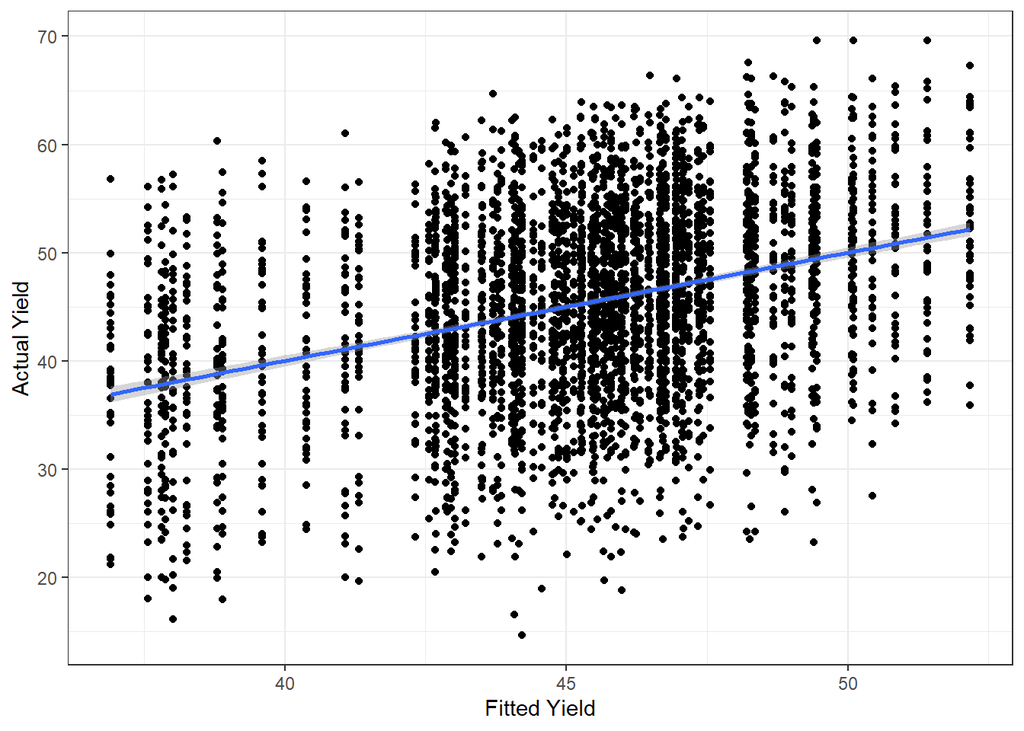

```r
all_county_years_beans$fitted <- lm_beanyields$fitted.values

ggplot(all_county_years_beans, mapping = aes(x = fitted, y = yield)) +
  geom_point() +
  theme_bw() +
  labs(x = "Fitted Yield", y = "Actual Yield") +
  geom_smooth(method = lm)
```

### Bonus: Find a package to make a county map of Iowa displaying some sort of information about yields or weather. Interpret your map.

### Bonus #2: Challenge question - map trends in corn yields by county across Iowa. Interpret your map.